# Tugas Statistika Pertemuan 9

## Load Dataset

```r
library(readxl)
library(dplyr)
```

```r
# Load HBAT Dataset
df_hbat_raw = read_excel("D:/Kuliah/Semester 1/Statistika dan Analisis Multivariat/Pertemuan 9/Multivariate_Data_Analysis_7e_Datasets_EXCEL.xlsx", sheet = "HBAT")

#Rename Columns
df_hbat = df_hbat_raw %>% rename("customer_type"="X1",
                                "industry_type"="X2",
                                "firm_size"="X3",
                                "region"="X4",
                                "distribution_system"="X5",
                                "product_quality"="X6",
                                "ecommerce_activities_website"="X7",
                                "technical_support"="X8",
                                "complaint_resolution"="X9",
                                "advertising"="X10",
                                "product_line"="X11",
                                "salesforce_image"="X12",
                                "competitive_pricing"="X13",
                                "warranty_and_claims"="X14",
                                "new_products"="X15",
                                "ordering_and_billing"="X16",
                                "price_flexibility"="X17",
                                "delivery_speed"="X18",
                                "satisfaction"="X19",
                                "likelihood_of_recommendation"="X20",
                                "likelihood_of_future_purchase"="X21",
                                "current_purchase_or_usage_level"="X22",
                                "consider_strategic_alliance_or_partnership_in_future"="X23"
                                )

df_hbat = as.data.frame(df_hbat)

# Print 6 Data
head(df_hbat)
```

```
##   ID customer_type industry_type firm_size region distribution_system
## 1  1             2             0         1      1                   1
## 2  2             3             1         0      0                   0
## 3  3             3             0         1      1                   1
## 4  4             1             1         1      1                   0
## 5  5             2             0         1      0                   1
## 6  6             1             1         0      1                   0
##   product_quality ecommerce_activities_website technical_support
## 1             8.5                          3.9               2.5
## 2             8.2                          2.7               5.1
## 3             9.2                          3.4               5.6
## 4             6.4                          3.3               7.0
## 5             9.0                          3.4               5.2
## 6             6.5                          2.8               3.1
##   complaint_resolution advertising product_line salesforce_image
```

[output cut: 34 more lines]

```r
# Load HBAT_MISSING
df_hbatm_raw = read_excel("D:/Kuliah/Semester 1/Statistika dan Analisis Multivariat/Pertemuan 9/Multivariate_Data_Analysis_7e_Datasets_EXCEL.xlsx", sheet = "HBAT_MISSING")
```

## Eksaminasi Grafis

### Univariate Profiling: Histogram

Examining the shape of the distribution Source: https://www.tutorialspoint.com/how-to-create-histogram-of-all-columns-in-an-r-data-frame#:~:text=More%20Detail-,To%20create%20histogram%20of%20all%20columns%20in%20an%20R%20data,single%20line%20code%20as%20hist.

```r
#install.packages("Hmisc")
library(Hmisc)
## Drop Non Metric Column
df_hbat_v = df_hbat[c(-1, -2, -3, -4, -5, -6, -24)]
df_hbat_nonmetric = df_hbat[c(2,3,4,5,6,24)]

head(df_hbat_v)
```

```
##   product_quality ecommerce_activities_website technical_support
## 1             8.5                          3.9               2.5
## 2             8.2                          2.7               5.1
## 3             9.2                          3.4               5.6
## 4             6.4                          3.3               7.0
## 5             9.0                          3.4               5.2
## 6             6.5                          2.8               3.1
##   complaint_resolution advertising product_line salesforce_image
## 1                  5.9         4.8          4.9              6.0
## 2                  7.2         3.4          7.9              3.1
## 3                  5.6         5.4          7.4              5.8
## 4                  3.7         4.7          4.7              4.5
## 5                  4.6         2.2          6.0              4.5
## 6                  4.1         4.0          4.3              3.7
##   competitive_pricing warranty_and_claims new_products ordering_and_billing
```

[output cut: 20 more lines]

```r
head(df_hbat_nonmetric)
```

```
##   customer_type industry_type firm_size region distribution_system
## 1             2             0         1      1                   1
## 2             3             1         0      0                   0
## 3             3             0         1      1                   1
## 4             1             1         1      1                   0
## 5             2             0         1      0                   1
## 6             1             1         0      1                   0
##   consider_strategic_alliance_or_partnership_in_future
## 1                                                    1
## 2                                                    0
## 3                                                    1
## 4                                                    0
## 5                                                    0
## 6                                                    0
```

[figure not shown]

```r
hist.data.frame(df_hbat_v)
```

From the histogram, most of the graph approaching normal distribution, but some graph distribution may slightly off like likelihood of future purchase, delivery speed, price flexibility, salesforce image, and competitive pricing.

### Boxplot

Source: https://stackoverflow.com/questions/11346880/r-plot-multiple-box-plots-using-columns-from-data-frame

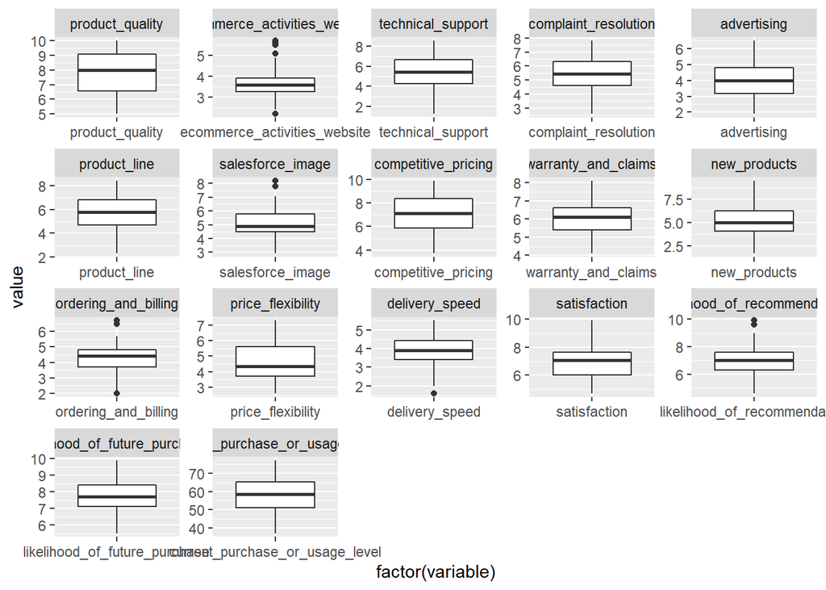

```r
library(reshape2)
library(ggplot2)

meltData <- melt(df_hbat_v)
p <- ggplot(meltData, aes(factor(variable), value))
p + geom_boxplot() + facet_wrap(~variable, scale="free")
```

```r
## Penanganan Missing Value
```

From the boxplot, there exist some of outlier in ecommerce activities website, salesforce image, ordering and billing, delivery speed, and likelihood of recommendation.

### Bivariate Profiling: Scatter Plot

Examining the relationship between variables Source: https://stackoverflow.com/questions/26623303/is-there-any-package-and-function-that-produce-this-image-in-r

```r
library(psych)
```

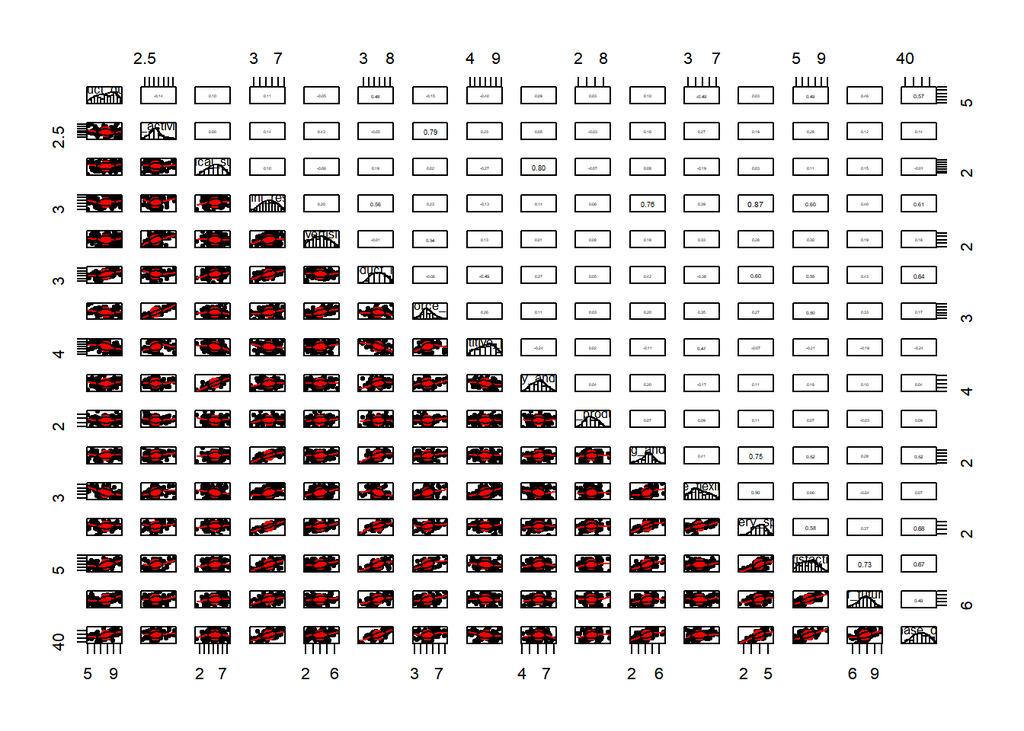

```r
pairs.panels(df_hbat_v[,-15], hist.col="white", scale=TRUE)
```

```r
print(cor(df_hbat_v[,c(1,2,3,4,5,6,7,8.9,10,11,12,13,14,15,16)]))
```

```
##                               product_quality ecommerce_activities_website
## product_quality                    1.00000000                -0.1371632174
## ecommerce_activities_website      -0.13716322                 1.0000000000
## technical_support                  0.09560045                 0.0008667887
## complaint_resolution               0.10637000                 0.1401792611
## advertising                       -0.05347313                 0.4298907110
## product_line                       0.47749341                -0.0526878383
## salesforce_image                  -0.15181287                 0.7915437115
## competitive_pricing               -0.40128188                 0.2294624014
## new_products                       0.02698820                -0.0274278083
## ordering_and_billing               0.10430307                 0.1561473316
## price_flexibility                 -0.49313812                 0.2706674197
## delivery_speed                     0.02771800                 0.1916360683
## satisfaction                       0.48632500                 0.2827450147
## likelihood_of_recommendation       0.44717105                 0.2219078477
## likelihood_of_future_purchase      0.46218901                 0.1173198060
##                               technical_support complaint_resolution
## product_quality                    0.0956004542           0.10637000
## ecommerce_activities_website       0.0008667887           0.14017926
## technical_support                  1.0000000000           0.09665660
## complaint_resolution               0.0966565978           1.00000000
## advertising                       -0.0628700668           0.19691685
## product_line                       0.1926254565           0.56141695
## salesforce_image                   0.0169905395           0.22975176
## competitive_pricing               -0.2707866821          -0.12795425
## new_products                      -0.0735789868           0.05940111
## ordering_and_billing               0.0801018246           0.75686859
## price_flexibility                 -0.1860963881           0.39450634
## delivery_speed                     0.0254406935           0.86509170
## satisfaction                       0.1125971788           0.60326260
## likelihood_of_recommendation       0.1880734315           0.45064377
## likelihood_of_future_purchase      0.1526817204           0.40080499
##                               advertising product_line salesforce_image
## product_quality               -0.05347313   0.47749341      -0.15181287
## ecommerce_activities_website   0.42989071  -0.05268784       0.79154371
## technical_support             -0.06287007   0.19262546       0.01699054
## complaint_resolution           0.19691685   0.56141695       0.22975176
## advertising                    1.00000000  -0.01155082       0.54220366
## product_line                  -0.01155082   1.00000000      -0.06131553
## salesforce_image               0.54220366  -0.06131553       1.00000000
```

[output cut: 73 more lines]

```
## product_quality                                  0.46218901
## ecommerce_activities_website                     0.11731981
## technical_support                                0.15268172
## complaint_resolution                             0.40080499
## advertising                                      0.19108795
## product_line                                     0.42835400
## salesforce_image                                 0.32875022
## competitive_pricing                             -0.19405508
## new_products                                    -0.03393140
## ordering_and_billing                             0.27821414
## price_flexibility                               -0.03697913
## delivery_speed                                   0.36536723
## satisfaction                                     0.73104896
## likelihood_of_recommendation                     0.69992347
## likelihood_of_future_purchase                    1.00000000
```

From the scatterplot and correlation, there are certain variable combination that has strong correlation, and that is :

- salesforce_image and ecommerce_activities_website
- salesforce_image and advertising
- ordering_and_billing and complaint_resolution
- delivery_speed and complaint_resolution
- satisfaction and complaint_resolution
- complaint_resolution and product_line
- ecommerce_activities_website and salesforce_image
- advertising and salesforce_image
- complaint_resolution and ordering and billing
- delivery_speed and product_line
- satisfaction and product_line
- satisfaction and salesforce_image
- delivery_speed and ordering_and_billing
- delivery_speed and complaint_resolution
- delivery_speed and salesforce_image
- delivery_speed and ordering_and_billing
- delivery_speed and satisfaction
- satisfaction and complaint_resolution
- satisfaction and product_line
- satisfaction and salesforce_image
- satisfaction and ordering_and_billing
- satisfaction and delivery_speed
- satisfaction and likelihood_of_recommendation
- satisfaction and likelihood_of_future_purchase
- likelihood_of_recommendation and satisfaction
- likelihood_of_future_purchase and likelihood_of_recommendation
- likelihood_of_future_purchase and satisfaction

Later, it is recommended to drop certain column to avoid multicolinearity (where correlation >=0.5) in case of regression analysis by dropping: salesforce_image, complaint_resolution, delivery_speed, satisfaction, likelihood_of_future_purchase

### Bivariate Profiling: Boxplot

Examining Group DIfferences Source: https://www.tutorialspoint.com/how-to-create-boxplot-for-multiple-categories-in-base-r

```r
str(df_hbat)
```

```
## 'data.frame':    100 obs. of  24 variables:
##  $ ID                                                  : num  1 2 3 4 5 6 7 8 9 10 ...
##  $ customer_type                                       : num  2 3 3 1 2 1 1 2 2 1 ...
##  $ industry_type                                       : num  0 1 0 1 0 1 1 0 1 0 ...
##  $ firm_size                                           : num  1 0 1 1 1 0 1 1 1 1 ...
##  $ region                                              : num  1 0 1 1 0 1 1 1 1 1 ...
##  $ distribution_system                                 : num  1 0 1 0 1 0 0 0 0 0 ...
##  $ product_quality                                     : num  8.5 8.2 9.2 6.4 9 6.5 6.9 6.2 5.8 6.4 ...
##  $ ecommerce_activities_website                        : num  3.9 2.7 3.4 3.3 3.4 2.8 3.7 3.3 3.6 4.5 ...
##  $ technical_support                                   : num  2.5 5.1 5.6 7 5.2 3.1 5 3.9 5.1 5.1 ...
##  $ complaint_resolution                                : num  5.9 7.2 5.6 3.7 4.6 4.1 2.6 4.8 6.7 6.1 ...
##  $ advertising                                         : num  4.8 3.4 5.4 4.7 2.2 4 2.1 4.6 3.7 4.7 ...
##  $ product_line                                        : num  4.9 7.9 7.4 4.7 6 4.3 2.3 3.6 5.9 5.7 ...
##  $ salesforce_image                                    : num  6 3.1 5.8 4.5 4.5 3.7 5.4 5.1 5.8 5.7 ...
##  $ competitive_pricing                                 : num  6.8 5.3 4.5 8.8 6.8 8.5 8.9 6.9 9.3 8.4 ...
##  $ warranty_and_claims                                 : num  4.7 5.5 6.2 7 6.1 5.1 4.8 5.4 5.9 5.4 ...
##  $ new_products                                        : num  4.3 4 4.6 3.6 4.5 9.5 2.5 4.8 4.4 5.3 ...
##  $ ordering_and_billing                                : num  5 3.9 5.4 4.3 4.5 3.6 2.1 4.3 4.4 4.1 ...
##  $ price_flexibility                                   : num  5.1 4.3 4 4.1 3.5 4.7 4.2 6.3 6.1 5.8 ...
##  $ delivery_speed                                      : num  3.7 4.9 4.5 3 3.5 3.3 2 3.7 4.6 4.4 ...
##  $ satisfaction                                        : num  8.2 5.7 8.9 4.8 7.1 4.7 5.7 6.3 7 5.5 ...
##  $ likelihood_of_recommendation                        : num  8 6.5 8.4 6 6.6 6.3 7.8 5.8 7.5 5.9 ...
##  $ likelihood_of_future_purchase                       : num  8.4 7.5 9 7.2 9 6.1 7.2 7.7 8.2 6.7 ...
##  $ current_purchase_or_usage_level                     : num  65.1 67.1 72.1 40.1 57.1 50.1 41.1 56.1 56.1 59.1 ...
##  $ consider_strategic_alliance_or_partnership_in_future: num  1 0 1 0 0 0 0 0 1 0 ...
```

```r
df_hbat_v_b = df_hbat[c(2,7,8)]
head(df_hbat_v_b)
```

```
##   customer_type product_quality ecommerce_activities_website
## 1             2             8.5                          3.9
## 2             3             8.2                          2.7
## 3             3             9.2                          3.4
## 4             1             6.4                          3.3
## 5             2             9.0                          3.4
## 6             1             6.5                          2.8
```

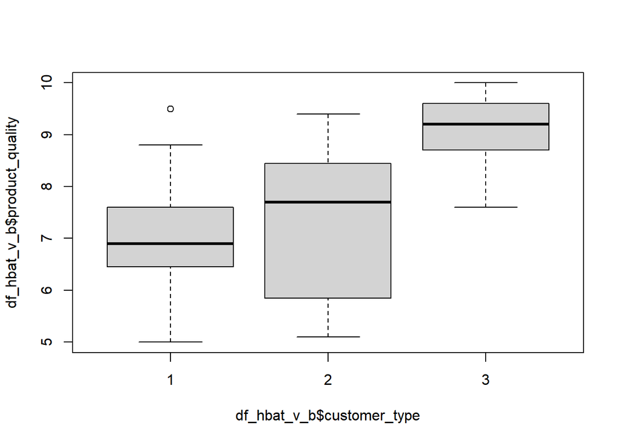

```r
boxplot(df_hbat_v_b$product_quality~df_hbat_v_b$customer_type)
```

In bivariate profiling, the use of boxplot is for telling us the variance difference of certain groups in the dataset. Here we take a little look at measuring product quality by customer type and as the graph depict, there is noticable different in how customer giving the product quality score.

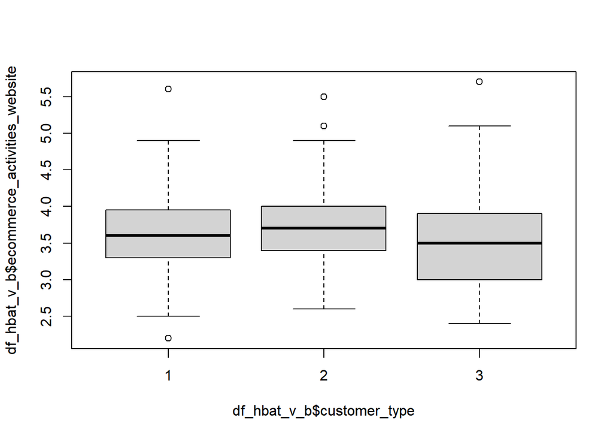

```r
boxplot(df_hbat_v_b$ecommerce_activities_website~df_hbat_v_b$customer_type)
```

Next, we take a look at measuring ecommerce activity website by customer type. There are hardly any different for each of the customer type in regards with ecommerce activities website.

### Multivariate Profiling: Faceting

```r
library(ggplot2)
str(df_hbat)
```

```
## 'data.frame':    100 obs. of  24 variables:
##  $ ID                                                  : num  1 2 3 4 5 6 7 8 9 10 ...
##  $ customer_type                                       : num  2 3 3 1 2 1 1 2 2 1 ...
##  $ industry_type                                       : num  0 1 0 1 0 1 1 0 1 0 ...
##  $ firm_size                                           : num  1 0 1 1 1 0 1 1 1 1 ...
##  $ region                                              : num  1 0 1 1 0 1 1 1 1 1 ...
##  $ distribution_system                                 : num  1 0 1 0 1 0 0 0 0 0 ...
##  $ product_quality                                     : num  8.5 8.2 9.2 6.4 9 6.5 6.9 6.2 5.8 6.4 ...
##  $ ecommerce_activities_website                        : num  3.9 2.7 3.4 3.3 3.4 2.8 3.7 3.3 3.6 4.5 ...
##  $ technical_support                                   : num  2.5 5.1 5.6 7 5.2 3.1 5 3.9 5.1 5.1 ...
##  $ complaint_resolution                                : num  5.9 7.2 5.6 3.7 4.6 4.1 2.6 4.8 6.7 6.1 ...
##  $ advertising                                         : num  4.8 3.4 5.4 4.7 2.2 4 2.1 4.6 3.7 4.7 ...
##  $ product_line                                        : num  4.9 7.9 7.4 4.7 6 4.3 2.3 3.6 5.9 5.7 ...
##  $ salesforce_image                                    : num  6 3.1 5.8 4.5 4.5 3.7 5.4 5.1 5.8 5.7 ...
##  $ competitive_pricing                                 : num  6.8 5.3 4.5 8.8 6.8 8.5 8.9 6.9 9.3 8.4 ...
##  $ warranty_and_claims                                 : num  4.7 5.5 6.2 7 6.1 5.1 4.8 5.4 5.9 5.4 ...
##  $ new_products                                        : num  4.3 4 4.6 3.6 4.5 9.5 2.5 4.8 4.4 5.3 ...
##  $ ordering_and_billing                                : num  5 3.9 5.4 4.3 4.5 3.6 2.1 4.3 4.4 4.1 ...
##  $ price_flexibility                                   : num  5.1 4.3 4 4.1 3.5 4.7 4.2 6.3 6.1 5.8 ...
##  $ delivery_speed                                      : num  3.7 4.9 4.5 3 3.5 3.3 2 3.7 4.6 4.4 ...
##  $ satisfaction                                        : num  8.2 5.7 8.9 4.8 7.1 4.7 5.7 6.3 7 5.5 ...
##  $ likelihood_of_recommendation                        : num  8 6.5 8.4 6 6.6 6.3 7.8 5.8 7.5 5.9 ...
##  $ likelihood_of_future_purchase                       : num  8.4 7.5 9 7.2 9 6.1 7.2 7.7 8.2 6.7 ...
##  $ current_purchase_or_usage_level                     : num  65.1 67.1 72.1 40.1 57.1 50.1 41.1 56.1 56.1 59.1 ...
##  $ consider_strategic_alliance_or_partnership_in_future: num  1 0 1 0 0 0 0 0 1 0 ...
```

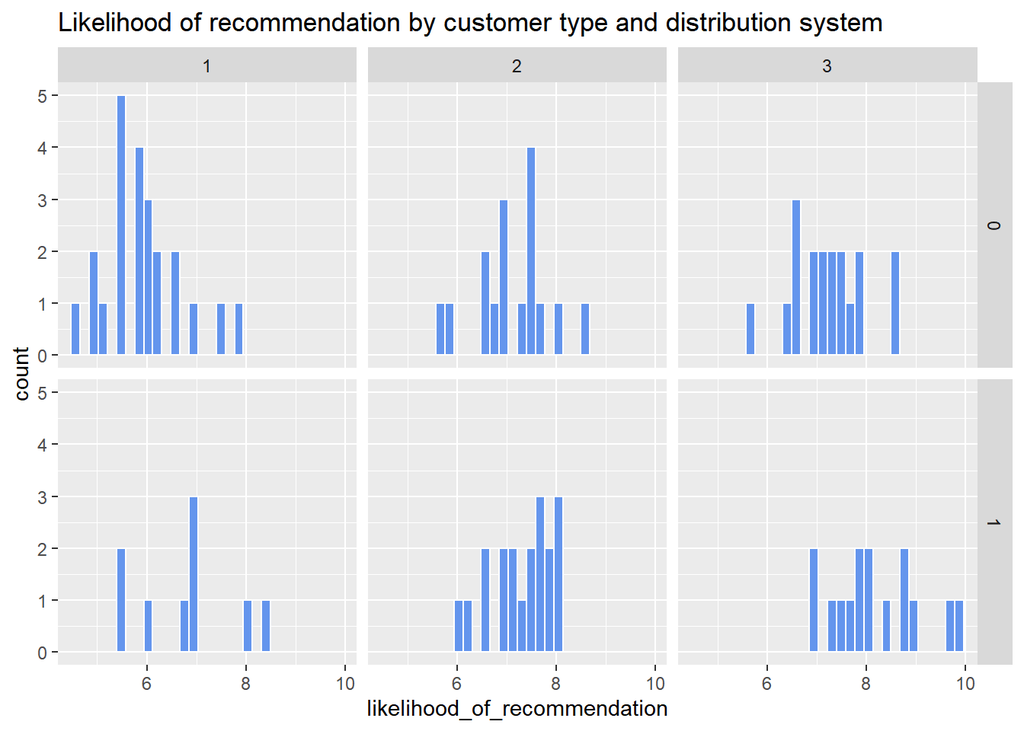

```r
#likelihood of recommendation by customer type and distribution system

# plot salary histograms by rank
ggplot(df_hbat, aes(x = likelihood_of_recommendation)) +
  geom_histogram(fill = "cornflowerblue",
                 color = "white") +
  facet_grid(distribution_system~customer_type) +
  labs(title = "Likelihood of recommendation by customer type and distribution system")
```

For the multivariate profiling, it is measure the likelihood of recommendation by customer type and distribution system. Some example insight can be derived is that customer type 1 with distribution system 0 tend to not recommending.

## Penanganan Missing Values

For the record, the data doesn’t have proper column name, this make the analysis much harder since there are no indicator of what the variable meant are.

### Data Preprocessing

```r
df_hbatm = df_hbatm_raw

# Replace . with NA
df_hbatm[df_hbatm=="."]<- NA
df_hbatm = as.data.frame(df_hbatm)

# Print 6 Data
str(df_hbatm)
```

```
## 'data.frame':    70 obs. of  15 variables:
##  $ ID : num  201 202 203 204 205 206 207 208 209 210 ...
##  $ V1 : chr  "3.3" NA "3" NA ...
##  $ V2 : chr  "0.9" "0.4" NA "1.5" ...
##  $ V3 : chr  "8.6" NA "9.1" NA ...
##  $ V4 : chr  "4" "2.5" "7.1" "4.8" ...
##  $ V5 : chr  "2.1" "1.2" "3.5" "1.9" ...
##  $ V6 : chr  "1.8" "1.7" "3.4" "2.5" ...
##  $ V7 : chr  "6.3" "5.2" NA "7.2" ...
##  $ V8 : chr  "41" "35" "55" "36" ...
##  $ V9 : chr  "4.5" "3.3" "5.2" NA ...
##  $ V10: chr  "0" "0" "0" "1" ...
##  $ V11: chr  "1" "1" "1" "0" ...
##  $ V12: chr  "0" "0" "1" "1" ...
##  $ V13: chr  "0" "0" "0" "0" ...
##  $ V14: chr  "2" "1" "3" "1" ...
```

```r
num_col = c(2,3,4,5,6,7,8,9,10)

df_hbatm_char = as.data.frame(df_hbatm[c(11,12,13,14,15)])

df_hbatm_num = as.data.frame(apply(df_hbatm[,num_col],2, as.numeric))

df_hbatm = data.frame(df_hbatm_num, df_hbatm_char)

str(df_hbatm)
```

```
## 'data.frame':    70 obs. of  14 variables:
##  $ V1 : num  3.3 NA 3 NA 5.1 4.6 NA 5.2 3.5 4.1 ...
##  $ V2 : num  0.9 0.4 NA 1.5 1.4 2.1 1.5 1.3 2.8 3.7 ...
##  $ V3 : num  8.6 NA 9.1 NA NA 7.9 NA 9.7 9.9 5.9 ...
##  $ V4 : num  4 2.5 7.1 4.8 4.8 5.8 4.8 6.1 3.5 NA ...
##  $ V5 : num  2.1 1.2 3.5 1.9 3.3 3.4 1.9 3.2 3.1 NA ...
##  $ V6 : num  1.8 1.7 3.4 2.5 2.6 2.8 2.5 3.9 1.7 NA ...
##  $ V7 : num  6.3 5.2 NA 7.2 3.8 4.7 7.2 6.7 5.4 NA ...
##  $ V8 : num  41 35 55 36 49 49 36 54 49 NA ...
##  $ V9 : num  4.5 3.3 5.2 NA 4.9 5.9 NA 5.8 5.4 NA ...
##  $ V10: chr  "0" "0" "0" "1" ...
##  $ V11: chr  "1" "1" "1" "0" ...
##  $ V12: chr  "0" "0" "1" "1" ...
##  $ V13: chr  "0" "0" "0" "0" ...
##  $ V14: chr  "2" "1" "3" "1" ...
```

### Missing data with finalfit

Source; https://cran.r-project.org/web/packages/finalfit/vignettes/missing.html

Examine data with ff_glimpse describe the summary of missing data

```r
#install.packages("naniar")
#install.packages("finalfit")
library(finalfit)
library(naniar)
library(dplyr)
#df_hbatm = df_hbatm[c(2,3,4,5,6)]
#df_hbatm = df_hbatm[20,]

explanatory = c("V1","V2","V3","V4","V5","V6","V7","V8","V9","V10","V11","V12","V14")
dependent = c("V13")

df_hbatm %>%
  ff_glimpse(dependent, explanatory)
```

```
## $Continuous
##    label var_type  n missing_n missing_percent mean  sd  min quartile_25 median
## V1    V1    <dbl> 49        21            30.0  4.0 0.9  2.8         3.2    3.8
## V2    V2    <dbl> 57        13            18.6  1.9 0.9  0.4         1.4    1.9
## V3    V3    <dbl> 53        17            24.3  8.1 1.4  5.0         6.7    8.2
## V4    V4    <dbl> 63         7            10.0  5.2 1.2  2.5         4.5    5.0
## V5    V5    <dbl> 61         9            12.9  2.9 0.8  1.1         2.2    3.0
## V6    V6    <dbl> 64         6             8.6  2.6 0.7  1.1         2.3    2.6
## V7    V7    <dbl> 61         9            12.9  6.8 1.7  1.7         5.6    6.8
## V8    V8    <dbl> 61         9            12.9 46.0 9.4 25.0        39.0   47.0
## V9    V9    <dbl> 63         7            10.0  4.8 0.8  3.3         4.2    4.9
##    quartile_75  max
## V1         4.7  6.5
## V2         2.5  3.8
## V3         9.2  9.9
## V4         5.9  7.8
## V5         3.4  4.6
## V6         3.0  4.0
## V7         8.2  9.9
## V8        54.0 65.0
## V9         5.2  6.2
##
## $Categorical
##     label var_type  n missing_n missing_percent levels_n levels levels_count
## V13   V13    <chr> 69         1             1.4        2      -            -
## V10   V10    <chr> 68         2             2.9        2      -            -
## V11   V11    <chr> 68         2             2.9        2      -            -
## V12   V12    <chr> 68         2             2.9        2      -            -
## V14   V14    <chr> 68         2             2.9        3      -            -
##     levels_percent
## V13              -
## V10              -
## V11              -
## V12              -
## V14              -
```

Identify missing values in each variables by creating plot for detecting pattern of missingness

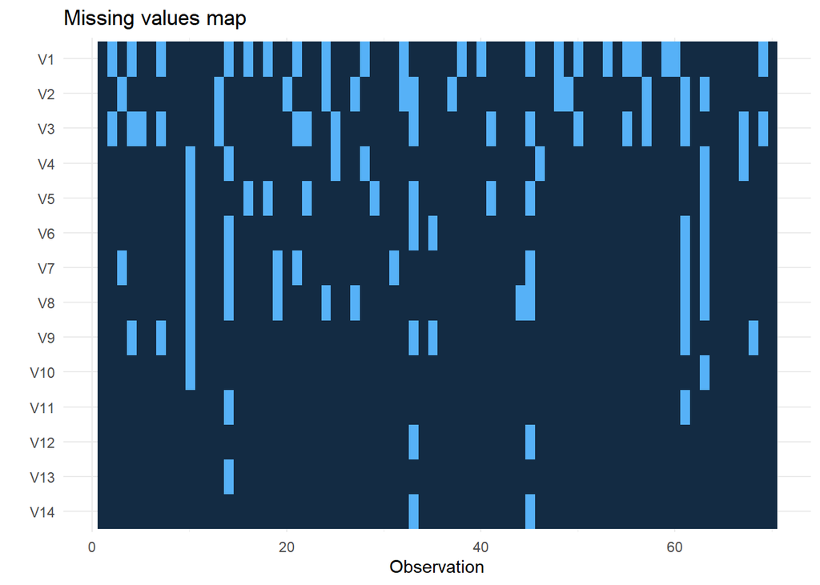

```r
df_hbatm %>% missing_plot()
```

From the pattern produce, it is more likely that missing value are having less occurence from V1 to V14. Since there are no information regarding the column context, we cannot derive any further analysis from this graph.

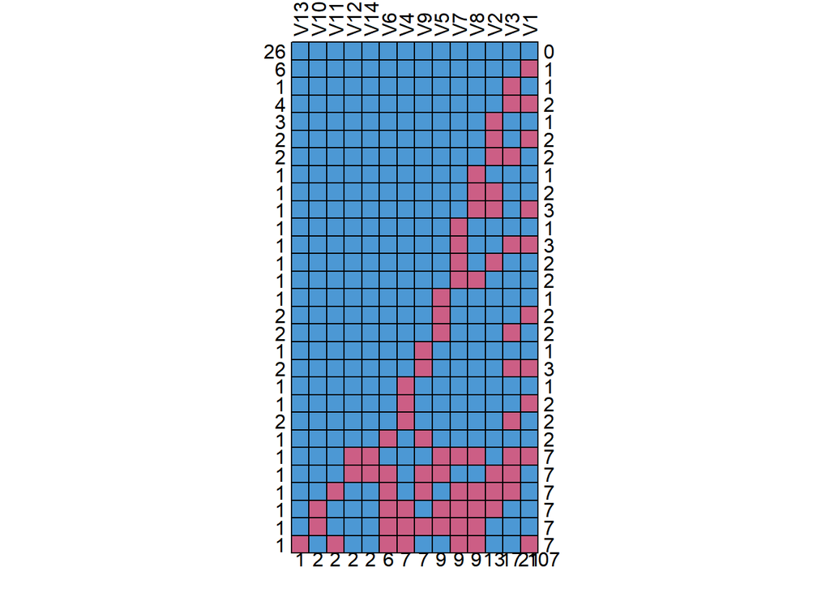

```
##    V13 V10 V11 V12 V14 V6 V4 V9 V5 V7 V8 V2 V3 V1
## 26   1   1   1   1   1  1  1  1  1  1  1  1  1  1   0
## 6    1   1   1   1   1  1  1  1  1  1  1  1  1  0   1
## 1    1   1   1   1   1  1  1  1  1  1  1  1  0  1   1
## 4    1   1   1   1   1  1  1  1  1  1  1  1  0  0   2
## 3    1   1   1   1   1  1  1  1  1  1  1  0  1  1   1
## 2    1   1   1   1   1  1  1  1  1  1  1  0  1  0   2
## 2    1   1   1   1   1  1  1  1  1  1  1  0  0  1   2
## 1    1   1   1   1   1  1  1  1  1  1  0  1  1  1   1
## 1    1   1   1   1   1  1  1  1  1  1  0  0  1  1   2
## 1    1   1   1   1   1  1  1  1  1  1  0  0  1  0   3
## 1    1   1   1   1   1  1  1  1  1  0  1  1  1  1   1
## 1    1   1   1   1   1  1  1  1  1  0  1  1  0  0   3
## 1    1   1   1   1   1  1  1  1  1  0  1  0  1  1   2
## 1    1   1   1   1   1  1  1  1  1  0  0  1  1  1   2
```

[output cut: 16 more lines]

```r
df_hbatm %>% missing_pattern(dependent, explanatory)
```

Describing the pattern of missingness between variables. 0 indicating missing data and 1 is non missing data. and the missing data is group by the pattern occured. The most left value is the amount of the missing value rows that has the same pattern and the most right is the amount of missing value per pattern it has. The bottom value represent the sum of missing value for each and all varables.

From the visualization, the occurence of missing value tend to decrease if the pattern containing more missing values.

Check for assotiation between missing data and observer data

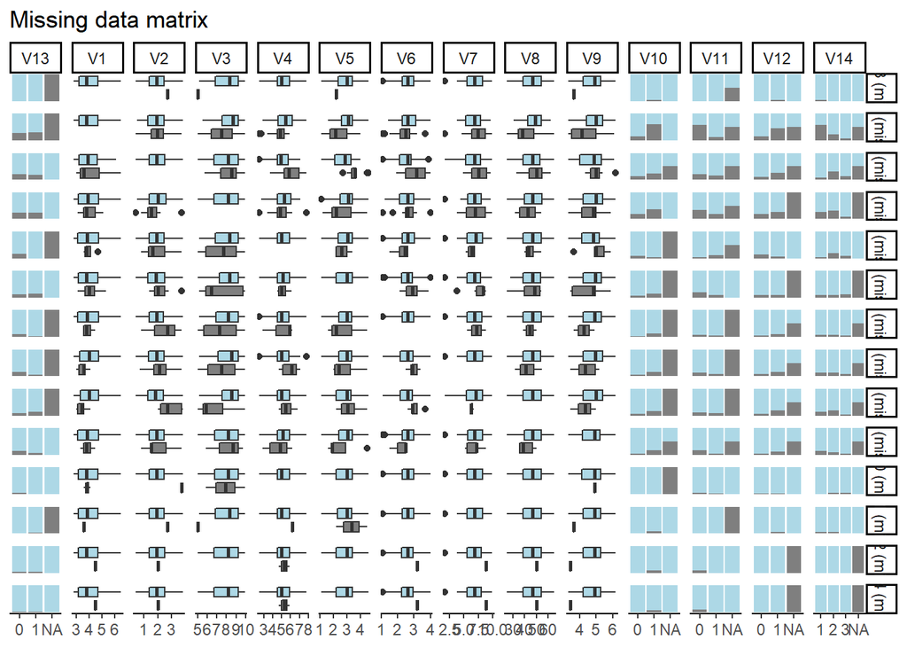

```r
df_hbatm %>%
  missing_pairs(dependent, explanatory, position = "fill")
```

### Another basic missingness summaries

miss_var_summary: return the number and the percentage of missing in each variable

```r
miss_var_summary(df_hbatm)
```

```
## # A tibble: 14 × 3
##    variable n_miss pct_miss
##    <chr>     <int>    <dbl>
##  1 V1           21    30
##  2 V3           17    24.3
##  3 V2           13    18.6
##  4 V5            9    12.9
##  5 V7            9    12.9
##  6 V8            9    12.9
##  7 V4            7    10
##  8 V9            7    10
##  9 V6            6     8.57
## 10 V10           2     2.86
## 11 V11           2     2.86
## 12 V12           2     2.86
## 13 V14           2     2.86
## 14 V13           1     1.43
```

miss_case_summary: return the number and the percentage of missing in each case (row)

```r
miss_case_summary(df_hbatm)
```

```
## # A tibble: 70 × 3
##     case n_miss pct_miss
##    <int>  <int>    <dbl>
##  1    10      7     50
##  2    14      7     50
##  3    33      7     50
##  4    45      7     50
##  5    61      7     50
##  6    63      7     50
##  7     4      3     21.4
##  8     7      3     21.4
##  9    21      3     21.4
## 10    24      3     21.4
## # … with 60 more rows
```

Missing data in tabulation, calculate the number of missing data in each variable and create tabulation to count how many variables that has certain amount of missing data.

```r
miss_var_table(df_hbatm)
```

```
## # A tibble: 8 × 3
##   n_miss_in_var n_vars pct_vars
##           <int>  <int>    <dbl>
## 1             1      1     7.14
## 2             2      4    28.6
## 3             6      1     7.14
## 4             7      2    14.3
## 5             9      3    21.4
## 6            13      1     7.14
## 7            17      1     7.14
## 8            21      1     7.14
```

Same as above but based on per row

```r
miss_case_table(df_hbatm)
```

```
## # A tibble: 5 × 3
##   n_miss_in_case n_cases pct_cases
##            <int>   <int>     <dbl>
## 1              0      26     37.1
## 2              1      15     21.4
## 3              2      19     27.1
## 4              3       4      5.71
## 5              7       6      8.57
```

In brief conclusion, the current best way to counter the missing values is by dropping the row contain missing values, since there are no context in the columns

```r
df_hbatm_dna = data.frame(na.omit(df_hbatm))

df_hbatm_dna
```

```
##     V1  V2  V3  V4  V5  V6  V7 V8  V9 V10 V11 V12 V13 V14
## 1  3.3 0.9 8.6 4.0 2.1 1.8 6.3 41 4.5   0   1   0   0   2
## 6  4.6 2.1 7.9 5.8 3.4 2.8 4.7 49 5.9   0   1   0   1   3
## 8  5.2 1.3 9.7 6.1 3.2 3.9 6.7 54 5.8   0   1   0   1   3
## 9  3.5 2.8 9.9 3.5 3.1 1.7 5.4 49 5.4   0   1   0   1   3
## 11 3.0 2.8 7.8 7.1 3.0 3.8 7.9 49 4.4   0   1   1   1   2
## 12 4.8 1.7 7.6 4.2 3.3 1.4 5.8 39 5.5   0   1   0   0   2
## 15 4.0 0.5 6.7 4.5 2.2 2.1 5.0 31 4.0   0   1   0   1   1
## 17 6.1 0.5 9.2 4.8 3.3 2.8 7.1 60 5.2   0   1   0   1   3
## 23 2.8 1.4 8.1 3.8 2.1 1.4 6.6 39 4.4   1   0   1   0   1
## 26 3.4 2.0 9.7 4.7 2.7 1.7 4.8 49 4.7   0   1   0   0   3
## 30 4.7 1.3 9.9 6.7 3.0 2.6 6.8 55 6.0   0   1   0   0   3
## 34 2.8 2.4 6.7 4.9 2.5 2.6 9.2 32 3.7   1   0   1   1   1
## 36 2.9 2.6 7.7 7.0 2.8 3.6 7.7 47 4.2   0   1   1   1   2
## 39 4.3 1.8 7.6 5.4 3.1 2.5 4.4 46 5.6   0   1   0   1   3
## 42 5.1 1.9 9.2 5.8 3.6 2.3 4.5 60 6.1   0   1   0   0   3
## 43 4.1 1.1 9.3 5.5 2.5 2.7 7.4 47 5.3   0   1   0   1   3
## 47 4.2 2.5 9.2 6.2 3.3 3.9 7.3 59 6.0   0   1   0   0   3
## 51 3.0 3.2 6.0 5.3 3.1 3.0 8.0 43 3.3   1   0   1   0   1
## 52 2.8 3.8 8.9 6.9 3.3 3.2 8.2 53 5.0   0   1   1   0   3
## 54 3.4 3.7 6.4 5.7 3.5 3.4 8.4 47 3.8   1   0   1   0   1
## 58 4.0 0.9 9.1 5.4 2.4 2.6 7.3 46 5.1   0   1   0   1   3
## 62 5.6 2.2 8.2 3.1 4.0 1.6 5.3 55 3.9   0   1   0   1   3
## 64 5.2 1.3 9.1 4.5 3.3 2.7 7.3 60 5.1   0   1   0   1   3
## 65 3.0 2.0 6.6 6.6 2.4 2.7 8.2 41 4.1   1   0   1   0   1
## 66 4.2 2.4 9.4 4.9 3.2 2.7 8.5 49 5.2   0   1   0   1   2
## 70 4.5 1.6 8.7 4.6 3.1 2.1 6.8 56 5.1   0   1   0   0   3
```

## Penanganan Outliers

From the boxplot, there exist some of outlier in ecommerce activities website, salesforce image, ordering and billing, delivery speed, and likelihood of recommendation. Therefore, lets look deeper and approach the outlier value:

```r
library(reshape2)
meltData <- melt(df_hbat_v)
```

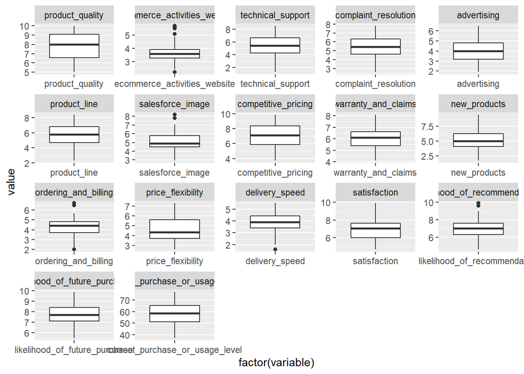

```r
p <- ggplot(meltData, aes(factor(variable), value))
p + geom_boxplot() + facet_wrap(~variable, scale="free")
```

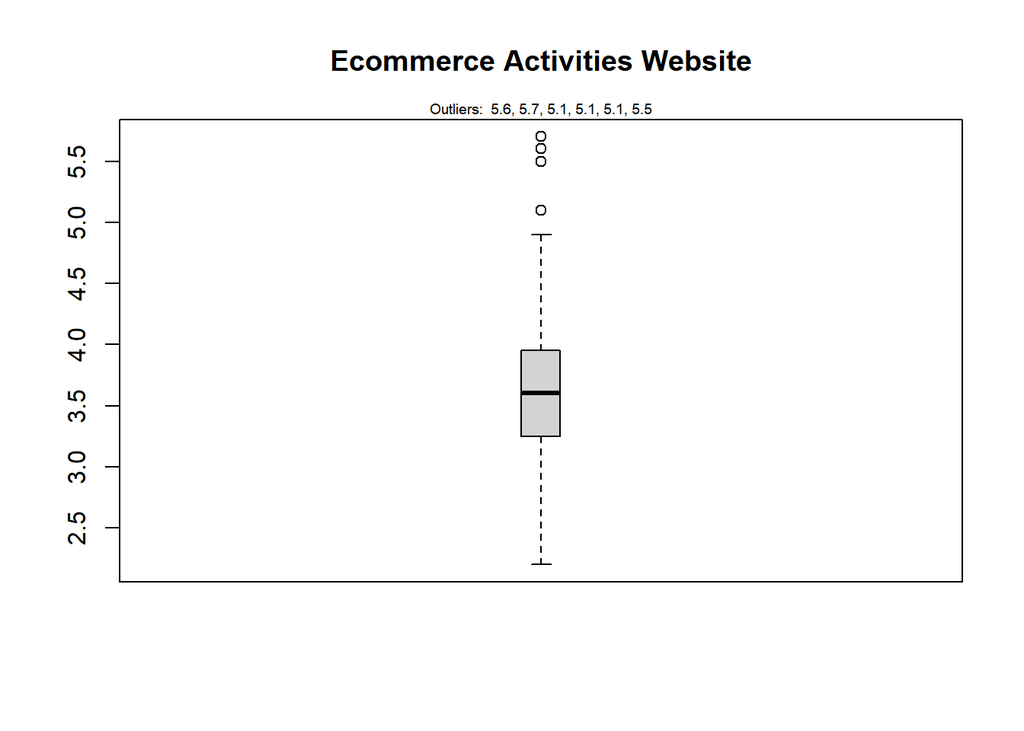

```r
df_hbat_uo = df_hbat_v
#df_hbat_uo <- as.data.frame(scale(df_hbat_uo))

#Ecommerce Activities Website
outlier_values = boxplot.stats(df_hbat_uo$ecommerce_activities_website)$out
boxplot(df_hbat_uo$ecommerce_activities_website, main="Ecommerce Activities Website", boxwex=0.1)
mtext(paste("Outliers: ", paste(outlier_values, collapse=", ")), cex=0.6)
```

From the ecommerce activities website, the outliers are in upper distribution. This may indicate that the customer very actively browse the website, therefore the outliers remain

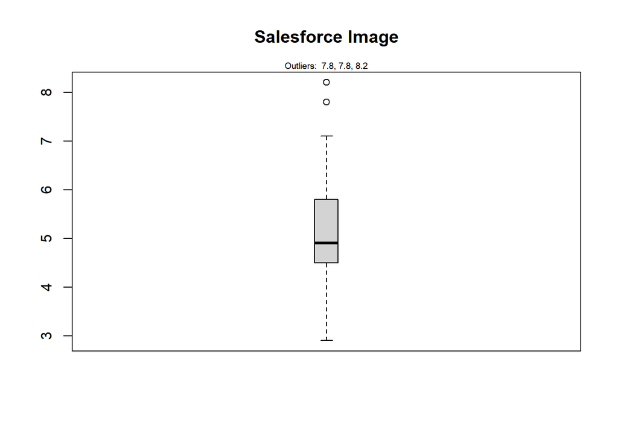

```r
#Salesforce image
outlier_values = boxplot.stats(df_hbat_uo$salesforce_image)$out
boxplot(df_hbat_uo$salesforce_image, main="Salesforce Image", boxwex=0.1)
mtext(paste("Outliers: ", paste(outlier_values, collapse=", ")), cex=0.6)
```

Here, the salesforce image may related to reputation, therefore there is possible to a salesforce to have a very good reputation therefore the outliers remain

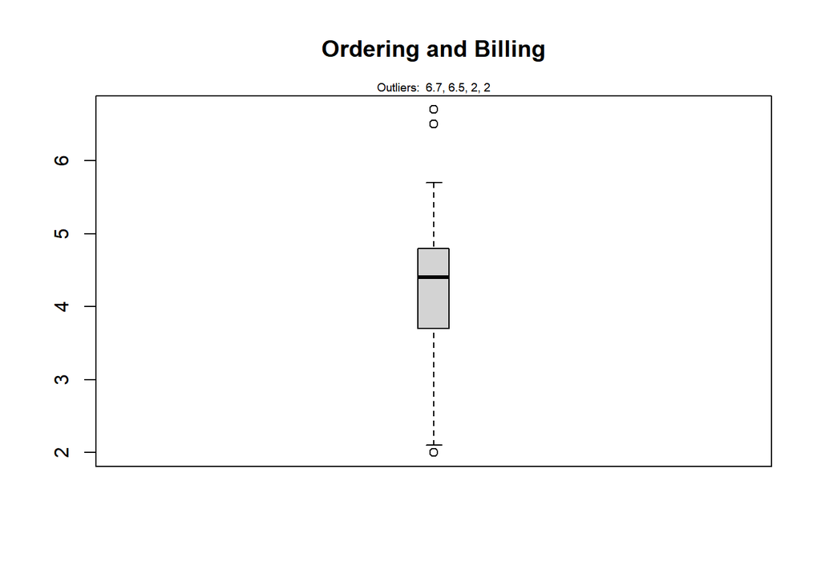

```r
#Ordering and Billing
outlier_values = boxplot.stats(df_hbat_uo$ordering_and_billing)$out
boxplot(df_hbat_uo$ordering_and_billing, main="Ordering and Billing", boxwex=0.1)
mtext(paste("Outliers: ", paste(outlier_values, collapse=", ")), cex=0.6)
```

Here, the ordering and billing also similar, there is posibility of customer purchasing in a very few amount of order and bill, therefore the outlier remain.

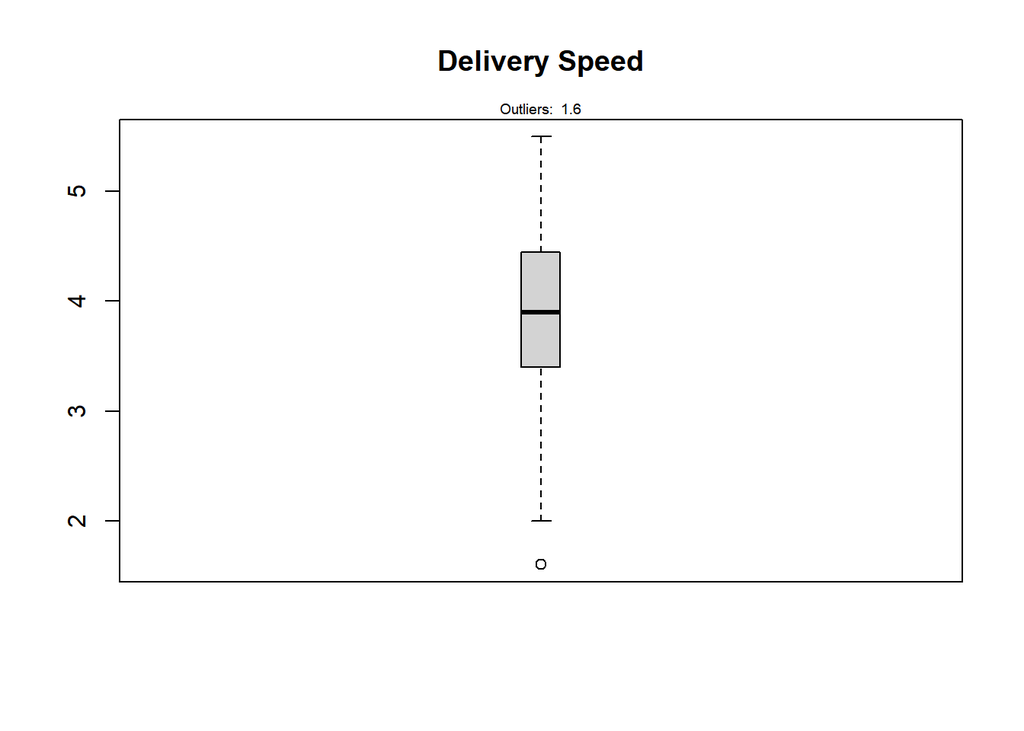

```r
#Delivery Speed
outlier_values = boxplot.stats(df_hbat_uo$delivery_speed)$out
boxplot(df_hbat_uo$delivery_speed, main="Delivery Speed", boxwex=0.1)
mtext(paste("Outliers: ", paste(outlier_values, collapse=", ")), cex=0.6)
```

Here the delivery speed can be very slow also, therefore the outlier remain

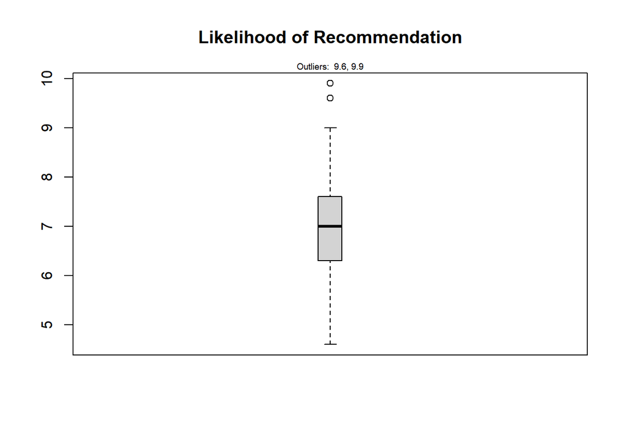

```r
#Likelihood of Recommendation
outlier_values = boxplot.stats(df_hbat_uo$likelihood_of_recommendation)$out
boxplot(df_hbat_uo$likelihood_of_recommendation, main="Likelihood of Recommendation", boxwex=0.1)
mtext(paste("Outliers: ", paste(outlier_values, collapse=", ")), cex=0.6)
```

Likelihood of recommendation outlier are also rational, therefore the outliers remain.

So in summary, from univariate outlier, there are no further process to encounter the outlier

### Penanganan Outliers Bivariat

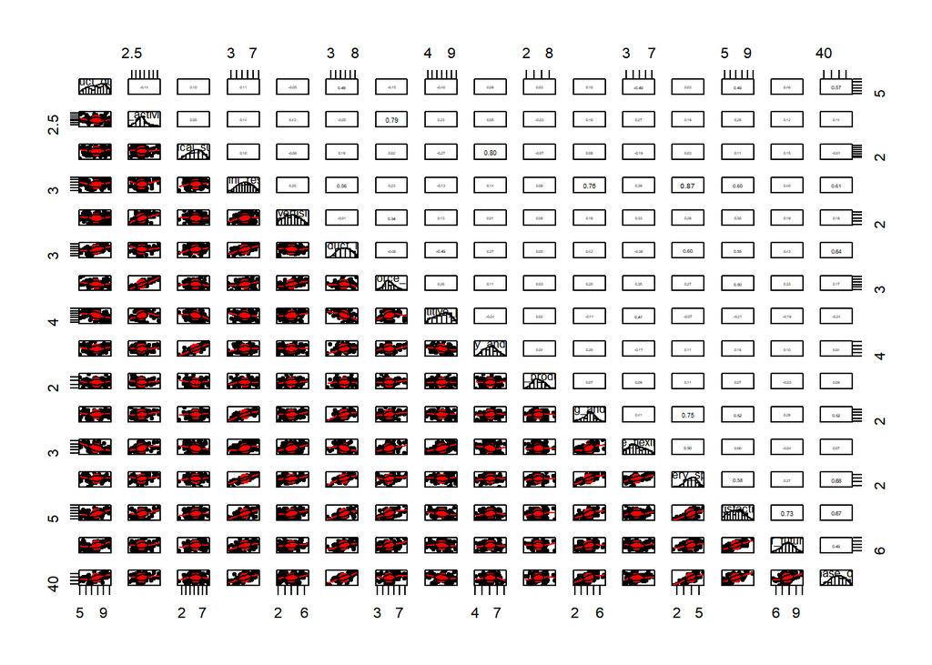

```r
library(psych)
df_hbat_bo = df_hbat_uo
#df_hbat_bo <- as.data.frame(scale(df_hbat_bo))

pairs.panels(df_hbat_bo[,-15], hist.col="white", scale=TRUE)
```

```r
str(df_hbat_bo)
```

```
## 'data.frame':    100 obs. of  17 variables:
##  $ product_quality                : num  8.5 8.2 9.2 6.4 9 6.5 6.9 6.2 5.8 6.4 ...
##  $ ecommerce_activities_website   : num  3.9 2.7 3.4 3.3 3.4 2.8 3.7 3.3 3.6 4.5 ...
##  $ technical_support              : num  2.5 5.1 5.6 7 5.2 3.1 5 3.9 5.1 5.1 ...
##  $ complaint_resolution           : num  5.9 7.2 5.6 3.7 4.6 4.1 2.6 4.8 6.7 6.1 ...
##  $ advertising                    : num  4.8 3.4 5.4 4.7 2.2 4 2.1 4.6 3.7 4.7 ...
##  $ product_line                   : num  4.9 7.9 7.4 4.7 6 4.3 2.3 3.6 5.9 5.7 ...
##  $ salesforce_image               : num  6 3.1 5.8 4.5 4.5 3.7 5.4 5.1 5.8 5.7 ...
##  $ competitive_pricing            : num  6.8 5.3 4.5 8.8 6.8 8.5 8.9 6.9 9.3 8.4 ...
##  $ warranty_and_claims            : num  4.7 5.5 6.2 7 6.1 5.1 4.8 5.4 5.9 5.4 ...
##  $ new_products                   : num  4.3 4 4.6 3.6 4.5 9.5 2.5 4.8 4.4 5.3 ...
##  $ ordering_and_billing           : num  5 3.9 5.4 4.3 4.5 3.6 2.1 4.3 4.4 4.1 ...
##  $ price_flexibility              : num  5.1 4.3 4 4.1 3.5 4.7 4.2 6.3 6.1 5.8 ...
##  $ delivery_speed                 : num  3.7 4.9 4.5 3 3.5 3.3 2 3.7 4.6 4.4 ...
##  $ satisfaction                   : num  8.2 5.7 8.9 4.8 7.1 4.7 5.7 6.3 7 5.5 ...
##  $ likelihood_of_recommendation   : num  8 6.5 8.4 6 6.6 6.3 7.8 5.8 7.5 5.9 ...
##  $ likelihood_of_future_purchase  : num  8.4 7.5 9 7.2 9 6.1 7.2 7.7 8.2 6.7 ...
##  $ current_purchase_or_usage_level: num  65.1 67.1 72.1 40.1 57.1 50.1 41.1 56.1 56.1 59.1 ...
```

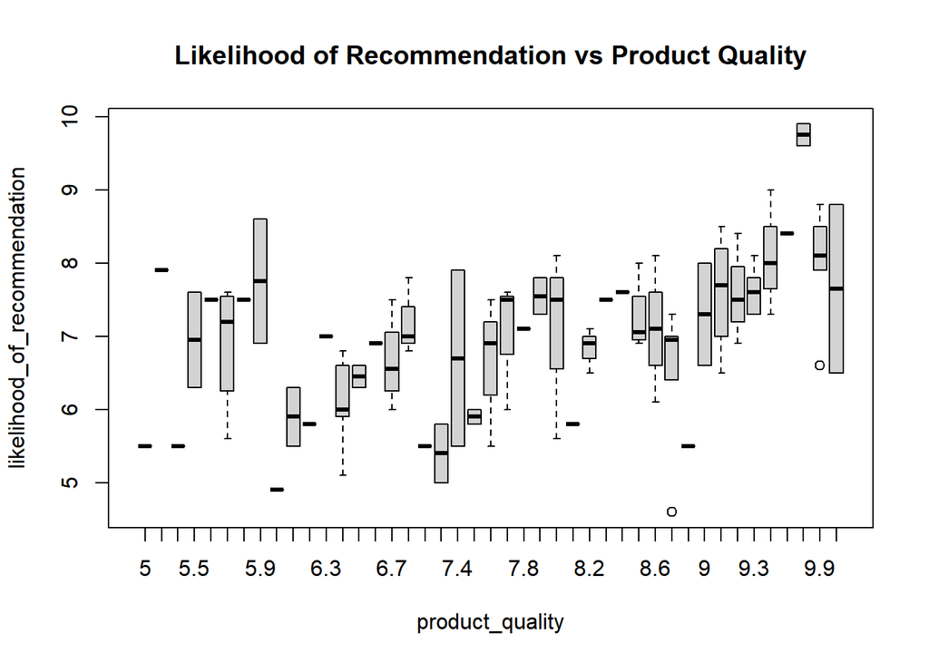

```r
boxplot(likelihood_of_recommendation ~ product_quality, data=df_hbat_bo, main="Likelihood of Recommendation vs Product Quality")
```

### Penanganan Outliers Multivariat

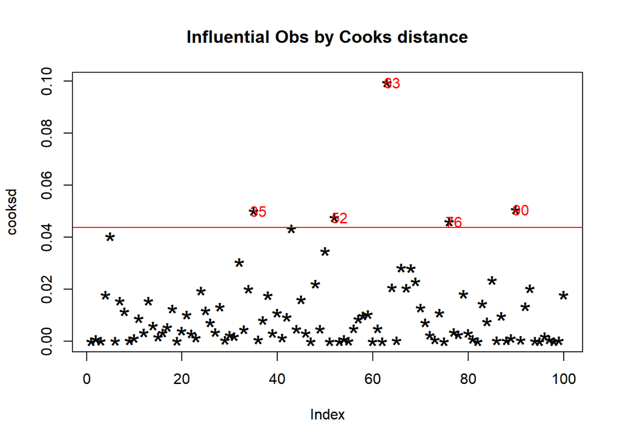

```
## integer(0)
```

```r
df_hbat_mo = df_hbat_bo
mod <- lm(likelihood_of_future_purchase ~ ., data=df_hbat_mo)
cooksd <- cooks.distance(mod)

plot(cooksd, pch="*", cex=2, main="Influential Obs by Cooks distance")+  # plot cook's distance
  abline(h = 4*mean(cooksd, na.rm=T), col="red")+  # add cutoff line
  text(x=1:length(cooksd)+1, y=cooksd, labels=ifelse(cooksd>4*mean(cooksd, na.rm=T),names(cooksd),""), col="red")  # add labels
```

From this graph, there exist outliers in row number 35, 52, 63, 76, and 90. Therefore we drop those row

```r
df_hbat_mo = df_hbat_mo[-c(35,52,63,76,90),]
df_hbat_nonmetric = df_hbat_nonmetric[-c(35,52,63,76,90),]
dim(df_hbat_mo)
```

```
## [1] 95 17
```

## Uji Normalisasi

Source: https://rpubs.com/maj_21m/835949

```r
library(tidyverse)
#install.packages("rstatix")
library(rstatix)
df_hbat_norm = df_hbat_mo

str(df_hbat_norm)
```

```
## 'data.frame':    95 obs. of  17 variables:
##  $ product_quality                : num  8.5 8.2 9.2 6.4 9 6.5 6.9 6.2 5.8 6.4 ...
##  $ ecommerce_activities_website   : num  3.9 2.7 3.4 3.3 3.4 2.8 3.7 3.3 3.6 4.5 ...
##  $ technical_support              : num  2.5 5.1 5.6 7 5.2 3.1 5 3.9 5.1 5.1 ...
##  $ complaint_resolution           : num  5.9 7.2 5.6 3.7 4.6 4.1 2.6 4.8 6.7 6.1 ...
##  $ advertising                    : num  4.8 3.4 5.4 4.7 2.2 4 2.1 4.6 3.7 4.7 ...
##  $ product_line                   : num  4.9 7.9 7.4 4.7 6 4.3 2.3 3.6 5.9 5.7 ...
##  $ salesforce_image               : num  6 3.1 5.8 4.5 4.5 3.7 5.4 5.1 5.8 5.7 ...
##  $ competitive_pricing            : num  6.8 5.3 4.5 8.8 6.8 8.5 8.9 6.9 9.3 8.4 ...
##  $ warranty_and_claims            : num  4.7 5.5 6.2 7 6.1 5.1 4.8 5.4 5.9 5.4 ...
##  $ new_products                   : num  4.3 4 4.6 3.6 4.5 9.5 2.5 4.8 4.4 5.3 ...
##  $ ordering_and_billing           : num  5 3.9 5.4 4.3 4.5 3.6 2.1 4.3 4.4 4.1 ...
##  $ price_flexibility              : num  5.1 4.3 4 4.1 3.5 4.7 4.2 6.3 6.1 5.8 ...
##  $ delivery_speed                 : num  3.7 4.9 4.5 3 3.5 3.3 2 3.7 4.6 4.4 ...
##  $ satisfaction                   : num  8.2 5.7 8.9 4.8 7.1 4.7 5.7 6.3 7 5.5 ...
##  $ likelihood_of_recommendation   : num  8 6.5 8.4 6 6.6 6.3 7.8 5.8 7.5 5.9 ...
##  $ likelihood_of_future_purchase  : num  8.4 7.5 9 7.2 9 6.1 7.2 7.7 8.2 6.7 ...
##  $ current_purchase_or_usage_level: num  65.1 67.1 72.1 40.1 57.1 50.1 41.1 56.1 56.1 59.1 ...
```

```r
all_var = names(df_hbat_norm)

df_hbat_norm %>%
  shapiro_test(all_var)
```

```
## # A tibble: 17 × 3
##    variable                        statistic       p
##    <chr>                               <dbl>   <dbl>
##  1 advertising                         0.978 0.112
##  2 competitive_pricing                 0.966 0.0149
##  3 complaint_resolution                0.987 0.494
##  4 current_purchase_or_usage_level     0.982 0.218
##  5 delivery_speed                      0.978 0.117
##  6 ecommerce_activities_website        0.960 0.00567
##  7 likelihood_of_future_purchase       0.985 0.349
##  8 likelihood_of_recommendation        0.988 0.556
##  9 new_products                        0.984 0.298
## 10 ordering_and_billing                0.974 0.0593
## 11 price_flexibility                   0.966 0.0154
## 12 product_line                        0.986 0.421
## 13 product_quality                     0.950 0.00118
## 14 salesforce_image                    0.979 0.120
## 15 satisfaction                        0.974 0.0530
## 16 technical_support                   0.986 0.437
## 17 warranty_and_claims                 0.992 0.865
```

### Q-Q Plot

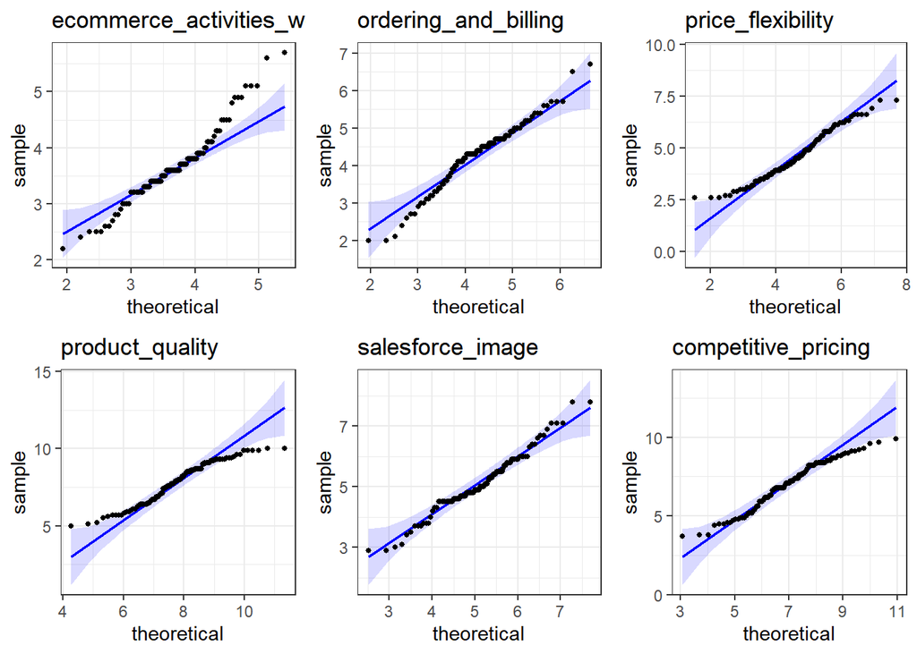

```r
library(ggplot2)
#install.packages("qqplotr")
library(qqplotr)
library(gridExtra)
p1<-ggplot(data = df_hbat_norm, mapping = aes(sample = ecommerce_activities_website)) +
  stat_qq_band(fill="blue",alpha = 0.15) +
  stat_qq_line(col="blue") +
  stat_qq_point(col="black",size=1)+
  labs(title = "ecommerce_activities_website")+theme_bw()

p2<-ggplot(data = df_hbat_norm, mapping = aes(sample = ordering_and_billing)) +
  stat_qq_band(fill="blue",alpha = 0.15) +
  stat_qq_line(col="blue") +
  stat_qq_point(col="black",size=1)+
  labs(title = "ordering_and_billing")+theme_bw()

p3<-ggplot(data = df_hbat_norm, mapping = aes(sample = price_flexibility)) +
  stat_qq_band(fill="blue",alpha = 0.15) +
  stat_qq_line(col="blue") +
  stat_qq_point(col="black",size=1)+
  labs(title = "price_flexibility")+theme_bw()

p4<-ggplot(data = df_hbat_norm, mapping = aes(sample = product_quality)) +
  stat_qq_band(fill="blue",alpha = 0.15) +
  stat_qq_line(col="blue") +
  stat_qq_point(col="black",size=1)+
  labs(title = "product_quality")+theme_bw()

p5<-ggplot(data = df_hbat_norm, mapping = aes(sample = salesforce_image)) +
  stat_qq_band(fill="blue",alpha = 0.15) +
  stat_qq_line(col="blue") +
  stat_qq_point(col="black",size=1)+
  labs(title = "salesforce_image")+theme_bw()

p6<-ggplot(data = df_hbat_norm, mapping = aes(sample = competitive_pricing)) +
  stat_qq_band(fill="blue",alpha = 0.15) +
  stat_qq_line(col="blue") +
  stat_qq_point(col="black",size=1)+
  labs(title = "competitive_pricing")+theme_bw()

# Arrange in a grid
grid.arrange(p1,p2,p3,p4,p5,p6, ncol=3)
```

Density Plot

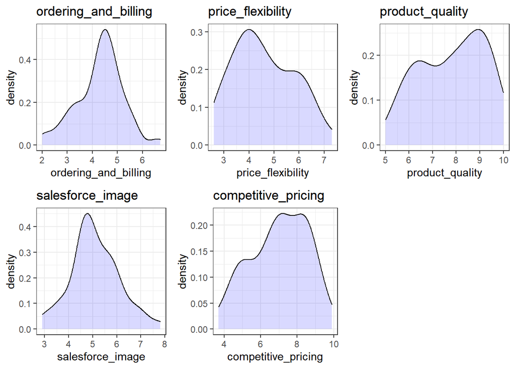

```r
p6<-ggplot(data=df_hbat_norm, aes(x = ecommerce_activities_website)) +
  geom_density(alpha = 0.15,fill="Purple")+
  labs(title = "ecommerce_activities_website")+theme_bw()

p7<-ggplot(data=df_hbat_norm, aes(x = ordering_and_billing)) +
  geom_density(alpha = 0.15,fill="blue")+
  labs(title = "ordering_and_billing")+theme_bw()

p8<-ggplot(data=df_hbat_norm, aes(x = price_flexibility)) +
  geom_density(alpha = 0.15,fill="blue")+
  labs(title = "price_flexibility")+theme_bw()

p9<-ggplot(data=df_hbat_norm, aes(x = product_quality)) +
  geom_density(alpha = 0.15,fill="blue")+
  labs(title = "product_quality")+theme_bw()

p10<-ggplot(data=df_hbat_norm, aes(x = salesforce_image)) +
  geom_density(alpha = 0.15,fill="blue")+
  labs(title = "salesforce_image")+theme_bw()

p11<-ggplot(data=df_hbat_norm, aes(x = competitive_pricing)) +
  geom_density(alpha = 0.15,fill="blue")+
  labs(title = "competitive_pricing")+theme_bw()

grid.arrange(p7,p8,p9,p10,p11, ncol=3)
```

Histogram

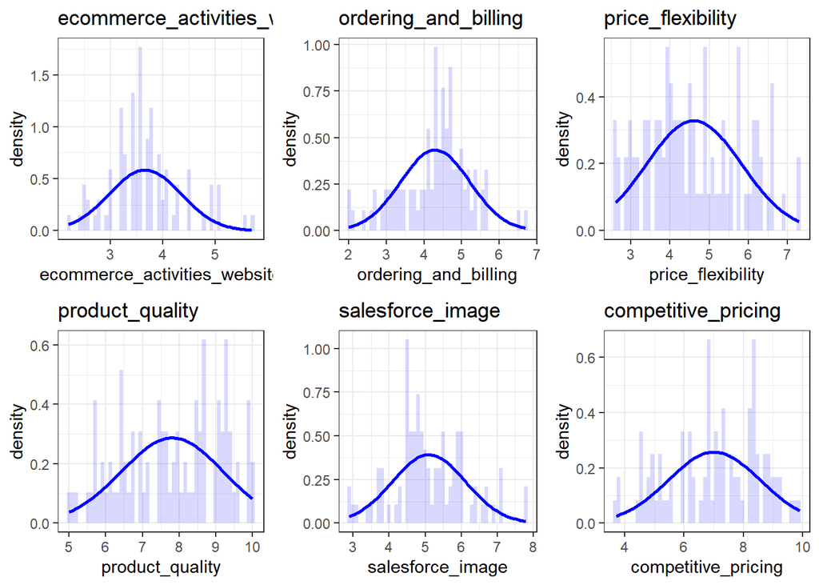

```r
p12<-ggplot(data=df_hbat_norm, aes(x=ecommerce_activities_website)) +
  geom_histogram(aes(x=ecommerce_activities_website, y=..density..), bins=50,fill="blue",alpha = 0.15) +
  stat_function(fun=dnorm, args = list(mean=mean(df_hbat_norm$ecommerce_activities_website),
                                       sd=sd(df_hbat_norm$ecommerce_activities_website)), color="blue",size=1)+
  labs(title = "ecommerce_activities_website")+theme_bw()

p13<-ggplot(data=df_hbat_norm, aes(x=ordering_and_billing)) +
  geom_histogram(aes(x=ordering_and_billing, y=..density..), bins=50,fill="blue",alpha = 0.15) +
  stat_function(fun=dnorm, args = list(mean=mean(df_hbat_norm$ordering_and_billing),
                                       sd=sd(df_hbat_norm$ordering_and_billing)), color="blue",size=1)+
  labs(title = "ordering_and_billing")+theme_bw()

p14<-ggplot(data=df_hbat_norm, aes(x=price_flexibility)) +
  geom_histogram(aes(x=price_flexibility, y=..density..), bins=50,fill="blue",alpha = 0.15) +
  stat_function(fun=dnorm, args = list(mean=mean(df_hbat_norm$price_flexibility),
                                       sd=sd(df_hbat_norm$price_flexibility)), color="blue",size=1)+
  labs(title = "price_flexibility")+theme_bw()

p15<-ggplot(data=df_hbat_norm, aes(x=product_quality)) +
  geom_histogram(aes(x=product_quality, y=..density..), bins=50,fill="blue",alpha = 0.15) +
  stat_function(fun=dnorm, args = list(mean=mean(df_hbat_norm$product_quality),
                                       sd=sd(df_hbat_norm$product_quality)), color="blue",size=1)+
  labs(title = "product_quality")+theme_bw()

p16<-ggplot(data=df_hbat_norm, aes(x=salesforce_image)) +
  geom_histogram(aes(x=salesforce_image, y=..density..), bins=50,fill="blue",alpha = 0.15) +
  stat_function(fun=dnorm, args = list(mean=mean(df_hbat_norm$salesforce_image),
                                       sd=sd(df_hbat_norm$salesforce_image)), color="blue",size=1)+
  labs(title = "salesforce_image")+theme_bw()

p17<-ggplot(data=df_hbat_norm, aes(x=competitive_pricing)) +
  geom_histogram(aes(x=competitive_pricing, y=..density..), bins=50,fill="blue",alpha = 0.15) +
  stat_function(fun=dnorm, args = list(mean=mean(df_hbat_norm$competitive_pricing),
                                       sd=sd(df_hbat_norm$competitive_pricing)), color="blue",size=1)+
  labs(title = "competitive_pricing")+theme_bw()

grid.arrange(p12,p13,p14,p15,p16,p17,ncol=3)
```

From this graph, it is known that ecommerce_activities_website, ordering_and_billing, and salesforce_image tend to have high peaks (kurtosis). Product_quality is more likely has two different distributions since it has two peaked, and price flexibility looks like a slightly off to the left (positive skew).

Therefore, we need to fixing the skewness accordingly

Source: https://www.datanovia.com/en/lessons/transform-data-to-normal-distribution-in-r/

```r
# Sqrt Transformation
df_hbat_norm$ecommerce_activities_website = sqrt(df_hbat_norm$ecommerce_activities_website)
df_hbat_norm$price_flexibility = sqrt(df_hbat_norm$price_flexibility)
df_hbat_norm$salesforce_image = sqrt(df_hbat_norm$salesforce_image)

# Sqrt(max(x+1)-x) Transformation
df_hbat_norm$ordering_and_billing = sqrt(max(df_hbat_norm$ordering_and_billing+1)-df_hbat_norm$ordering_and_billing)
df_hbat_norm$competitive_pricing = sqrt(max(df_hbat_norm$competitive_pricing+1)-df_hbat_norm$competitive_pricing)
df_hbat_norm$product_quality = sqrt(max(df_hbat_norm$product_quality+1)-df_hbat_norm$product_quality)

df_hbat_norm %>%
  shapiro_test(all_var)
```

```
## # A tibble: 17 × 3
##    variable                        statistic       p
##    <chr>                               <dbl>   <dbl>
##  1 advertising                         0.978 0.112
##  2 competitive_pricing                 0.978 0.117
##  3 complaint_resolution                0.987 0.494
##  4 current_purchase_or_usage_level     0.982 0.218
##  5 delivery_speed                      0.978 0.117
##  6 ecommerce_activities_website        0.974 0.0586
##  7 likelihood_of_future_purchase       0.985 0.349
##  8 likelihood_of_recommendation        0.988 0.556
##  9 new_products                        0.984 0.298
## 10 ordering_and_billing                0.975 0.0657
## 11 price_flexibility                   0.974 0.0526
## 12 product_line                        0.986 0.421
## 13 product_quality                     0.960 0.00517
## 14 salesforce_image                    0.981 0.181
## 15 satisfaction                        0.974 0.0530
## 16 technical_support                   0.986 0.437
## 17 warranty_and_claims                 0.992 0.865
```

Here the normalisation has been done using square root method, but for product_quality, the p-value still < 0.05 regarding the operation has been done like log transformation and inverse transformation

## Uji Korelasi

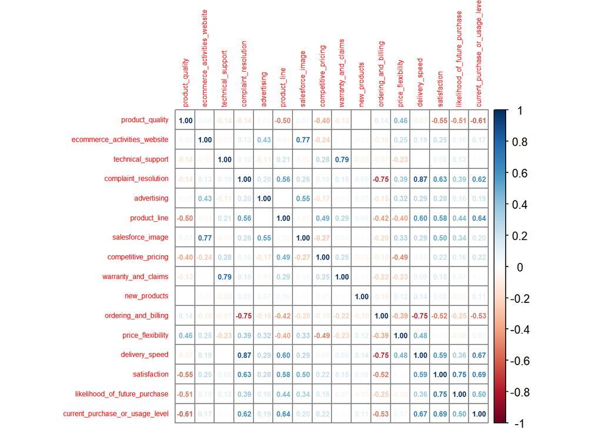

```r
df_hbat_cor = df_hbat_norm[c(-15)]

#install.packages("corrplot")
library(psych)
library(corrplot)
corrplot(cor(df_hbat_cor, df_hbat_cor),
         method = c("number"),
         #bg = "grey10",
         addgrid.col = "gray50",
         tl.cex=0.5,
         number.cex=0.5)
```

Later, it is recommended to drop certain column to avoid multicolinearity (where correlation >=0.5) in case of regression analysis by dropping: salesforce_image, complaint_resolution, delivery_speed, satisfaction, likelihood_of_future_purchase, warranty_and_claims, product_quality, current_purchase_or_usage_level

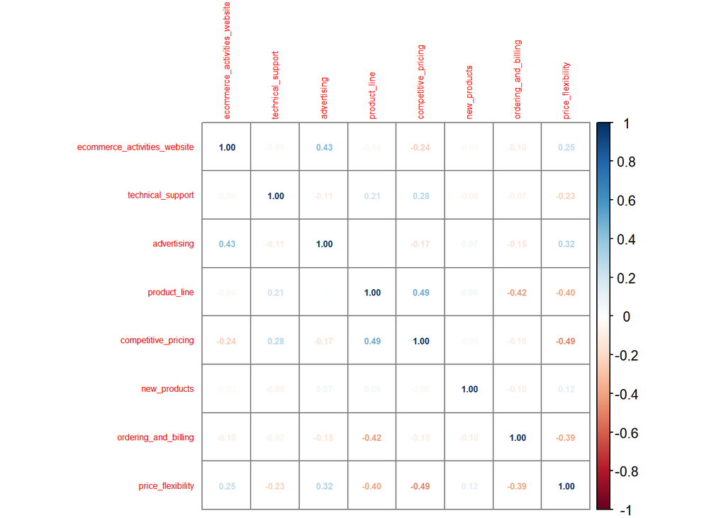

```r
df_hbat_cor = df_hbat_cor[c(-1, -7, -4, -9, -13, -14, -15, -16)]

corrplot(cor(df_hbat_cor, df_hbat_cor),
         method = c("number"),
         #bg = "grey10",
         addgrid.col = "gray50",
         tl.cex=0.5,
         number.cex=0.5)
```

## Uji Linieritas dan Uji Homoskesdastisitas

```r
df_hbat_lin = df_hbat_cor

df_hbat_lin = data.frame(df_hbat_lin,df_hbat_norm$likelihood_of_recommendation)
head(df_hbat_lin)
```

```
##   ecommerce_activities_website technical_support advertising product_line
## 1                     1.974842               2.5         4.8          4.9
## 2                     1.643168               5.1         3.4          7.9
## 3                     1.843909               5.6         5.4          7.4
## 4                     1.816590               7.0         4.7          4.7
## 5                     1.843909               5.2         2.2          6.0
## 6                     1.673320               3.1         4.0          4.3
##   competitive_pricing new_products ordering_and_billing price_flexibility
## 1            2.024846          4.3             1.643168          2.258318
## 2            2.366432          4.0             1.949359          2.073644
## 3            2.529822          4.6             1.516575          2.000000
## 4            1.449138          3.6             1.843909          2.024846
## 5            2.024846          4.5             1.788854          1.870829
## 6            1.549193          9.5             2.024846          2.167948
##   df_hbat_norm.likelihood_of_recommendation
## 1                                       8.0
## 2                                       6.5
## 3                                       8.4
## 4                                       6.0
## 5                                       6.6
## 6                                       6.3
```

```r
model = lm(df_hbat_norm.likelihood_of_recommendation~. , data = df_hbat_lin)
model
```

```
##
## Call:
## lm(formula = df_hbat_norm.likelihood_of_recommendation ~ ., data = df_hbat_lin)
##
## Coefficients:
##                  (Intercept)  ecommerce_activities_website
##                     6.022224                      1.052055
##            technical_support                   advertising
##                     0.069744                      0.079355
##                 product_line           competitive_pricing
##                     0.225823                     -0.051877
##                 new_products          ordering_and_billing
##                    -0.001857                     -1.271459
##            price_flexibility
##                    -0.261284
```

```r
summary(model)
```

```
##
## Call:
## lm(formula = df_hbat_norm.likelihood_of_recommendation ~ ., data = df_hbat_lin)
##
## Residuals:
##      Min       1Q   Median       3Q      Max
## -2.19738 -0.56841 -0.04715  0.53989  2.34165
##
## Coefficients:
##                               Estimate Std. Error t value Pr(>|t|)
## (Intercept)                   6.022224   2.862192   2.104   0.0383 *
## ecommerce_activities_website  1.052055   0.605923   1.736   0.0861 .
## technical_support             0.069744   0.064918   1.074   0.2857
## advertising                   0.079355   0.096778   0.820   0.4145
## product_line                  0.225823   0.110139   2.050   0.0434 *
## competitive_pricing          -0.051877   0.301010  -0.172   0.8636
## new_products                 -0.001857   0.064009  -0.029   0.9769
## ordering_and_billing         -1.271459   0.566680  -2.244   0.0274 *
## price_flexibility            -0.261284   0.560774  -0.466   0.6424
## ---
## Signif. codes:  0 '***' 0.001 '**' 0.01 '*' 0.05 '.' 0.1 ' ' 1
##
## Residual standard error: 0.9058 on 86 degrees of freedom
## Multiple R-squared:  0.3262, Adjusted R-squared:  0.2635
## F-statistic: 5.203 on 8 and 86 DF,  p-value: 2.582e-05
```

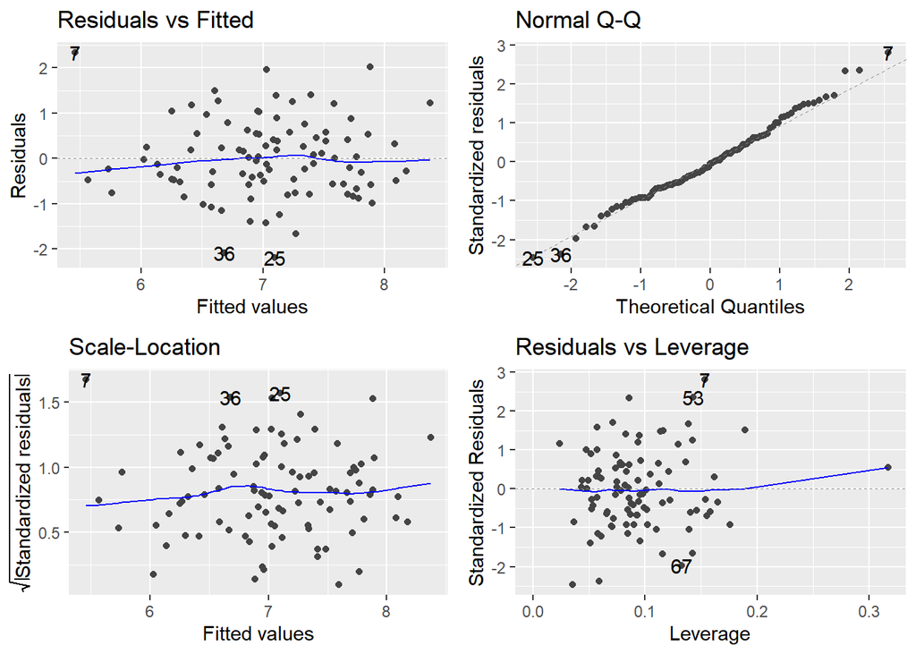

```r
#install.packages("ggfortify")
library(ggfortify)
autoplot(model)
```

The description are available here: http://www.sthda.com/english/articles/39-regression-model-diagnostics/161-linear-regression-assumptions-and-diagnostics-in-r-essentials/#linearity-of-the-data